# STDS GROUP ASSIGNMENT

# GENERALIZED LINEAR REGRESSION MODEL

```r
set.seed(42)

#Prepare the split for train and test dataset

Split <- floor(0.80 * nrow(movies_new))

#Getting indices of the dataset

Trainset_indices <- sample(seq_len(nrow(movies_new)), size = Split)

#Preparing train and testing dataset
TrainingDataSet <- movies_new[Trainset_indices, ]
TestDataSet <- movies_new[-Trainset_indices, ]

# Check number of rows in every set
nrow(movies_new)
```

```
## [1] 580
```

```r
nrow(TrainingDataSet)
```

```
## [1] 464
```

```r
nrow(TestDataSet)
```

```
## [1] 116
```

```r
# Training the model on the movies dataset.(GENERALIZED LINEAR MODEL)
Full_linear_model <-lm(vote_average~release_date+original_language+genre_ids+popularity+vote_count+runtime+budget+revenue, data = TrainingDataSet)
# Check the summary of the model
summary(Full_linear_model)
```

```
##
## Call:
## lm(formula = vote_average ~ release_date + original_language +
##     genre_ids + popularity + vote_count + runtime + budget +
##     revenue, data = TrainingDataSet)
##
## Residuals:
##      Min       1Q   Median       3Q      Max
## -2.37936 -0.06233  0.00000  0.11575  0.84704
##
## Coefficients: (1 not defined because of singularities)
##                                           Estimate Std. Error t value Pr(>|t|)
## (Intercept)                              7.514e+00  6.304e-01  11.919  < 2e-16
## release_date                            -2.526e-05  6.840e-06  -3.693 0.000277
## original_languagede                     -2.027e-01  6.878e-01  -0.295 0.768433
## original_languageen                     -3.706e-01  4.369e-01  -0.848 0.397232
## original_languagees                     -1.761e-01  6.061e-01  -0.291 0.771664
## original_languagefr                     -2.100e-01  4.457e-01  -0.471 0.637991
## original_languageit                     -1.641e-02  4.433e-01  -0.037 0.970508
## original_languageja                      2.669e-01  4.938e-01   0.541 0.589369
## original_languageru                     -5.423e-01  6.347e-01  -0.854 0.393770
## original_languagesv                      6.002e-04  4.896e-01   0.001 0.999023
## original_languagezh                     -2.770e-01  7.571e-01  -0.366 0.714776
## genre_ids10402, 16, 35, 10751           -7.671e-01  6.186e-01  -1.240 0.216212
## genre_ids10402, 35                       3.951e-03  6.044e-01   0.007 0.994791
## genre_ids10402, 35, 10749               -3.033e-01  5.243e-01  -0.578 0.563529
## genre_ids10749, 18                      -2.249e-01  5.322e-01  -0.423 0.673004
## genre_ids10749, 18, 10402                8.684e-02  6.197e-01   0.140 0.888686
## genre_ids10749, 18, 10752               -1.992e-01  6.073e-01  -0.328 0.743161
## genre_ids10749, 18, 35                   1.821e-02  6.053e-01   0.030 0.976024
## genre_ids10749, 35, 10751, 14           -1.165e+00  6.042e-01  -1.927 0.055191
## genre_ids10749, 35, 18                  -2.511e-02  5.299e-01  -0.047 0.962239
## genre_ids10749, 878                      4.177e-01  6.179e-01   0.676 0.499656
## genre_ids10751, 10402, 16, 18, 35       -5.510e-01  6.040e-01  -0.912 0.362590
## genre_ids10751, 12, 35, 878, 80         -1.100e+00  6.042e-01  -1.820 0.070052
## genre_ids10751, 14, 16, 10749           -4.989e-01  7.791e-01  -0.640 0.522558
## genre_ids10751, 16, 10402               -1.132e+00  6.061e-01  -1.867 0.063203
## genre_ids10751, 16, 10749               -8.423e-01  6.343e-01  -1.328 0.185560
## genre_ids10751, 16, 10770                3.210e-01  6.100e-01   0.526 0.599278
## genre_ids10751, 16, 12                  -8.959e-01  5.535e-01  -1.619 0.106893
```

[output cut: 440 more lines]

```
## genre_ids9648, 53, 10749
## genre_ids9648, 53, 10752
## genre_ids9648, 53, 80
## genre_ids9648, 80, 53
## popularity
## vote_count                              ***
## runtime
## budget
## revenue
## ---
## Signif. codes:  0 '***' 0.001 '**' 0.01 '*' 0.05 '.' 0.1 ' ' 1
##
## Residual standard error: 0.427 on 227 degrees of freedom
## Multiple R-squared:  0.7205, Adjusted R-squared:  0.4299
## F-statistic:  2.48 on 236 and 227 DF,  p-value: 6.597e-12
```

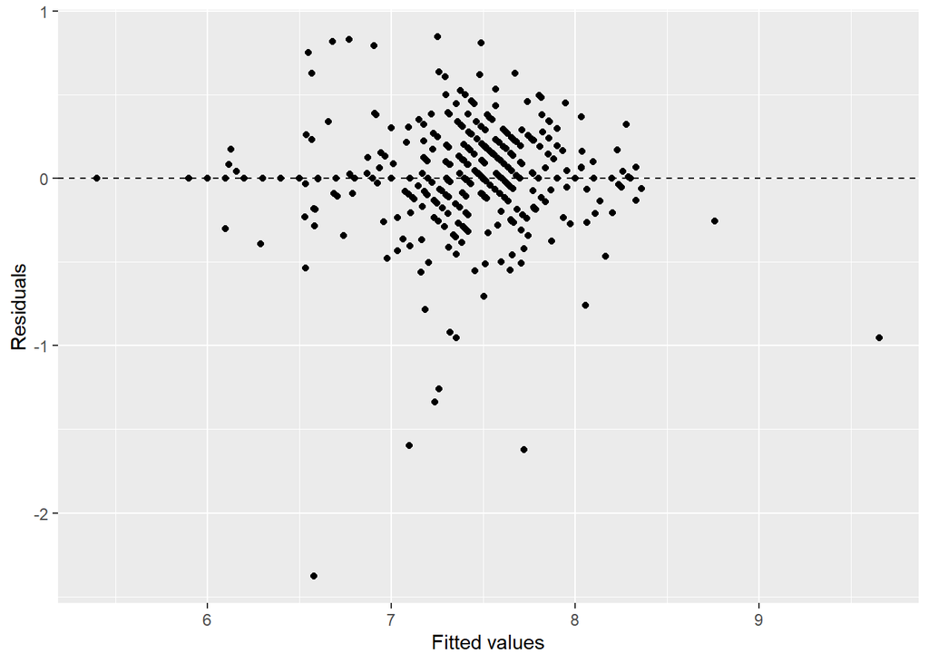

```r
#Model interpretation

ggplot(data = Full_linear_model, aes(x = .fitted, y = .resid)) +
  geom_point() +
  geom_hline(yintercept = 0, linetype = "dashed") +
  xlab("Fitted values") +
  ylab("Residuals")
```

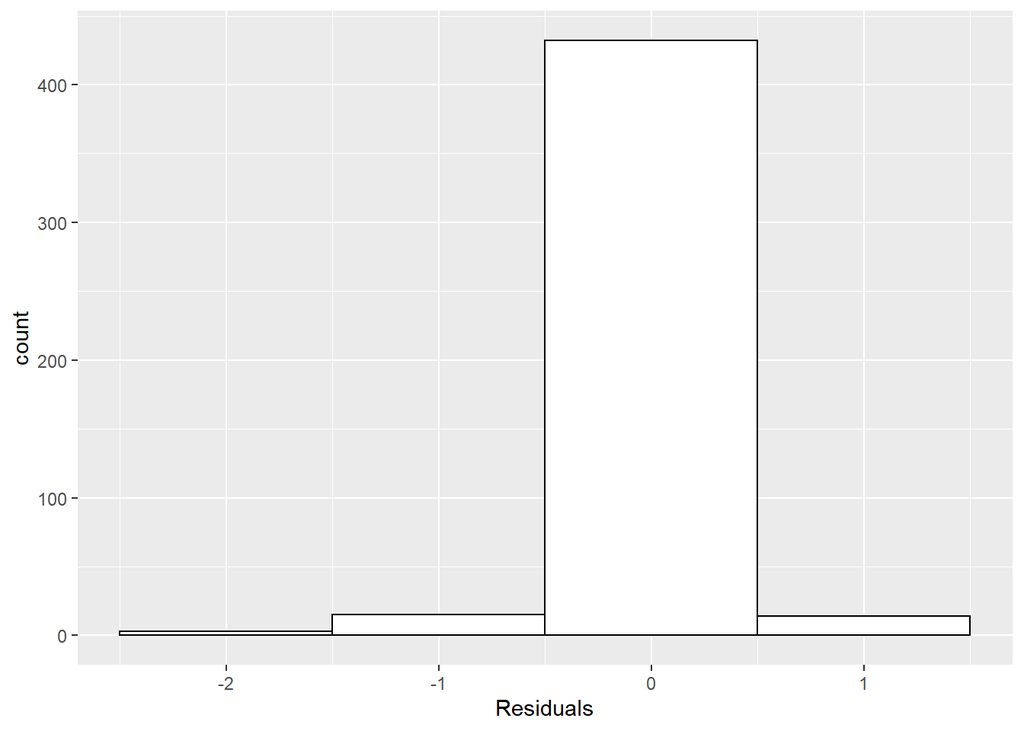

```r
#Showing the residuals
ggplot(data = Full_linear_model, aes(x = .resid)) +
  geom_histogram(binwidth = 1, fill='white', color='black') +
  xlab("Residuals")
```

As I had no much time, I didn’t do the other models. Please mention in the report that we will be doing logistic regression, pruned tree, unpruned tree and random forest.

By selecting the best model will do the testing for the dataset. will select best model by the evaluation measures such as accuracy, precision, recall and F1.

As to get an idea, This is the function that we are going to use, Evaluation_measures <- function(name = NA, tn, fp, fn, tp) {

accuracy = (tp+tn)/(tp+tn+fp+fn)

precision = tp/(tp+fp)

recall = tp/(tp+fn)

F1 = 2 * ((precision * recall)/(precision + recall))

output = data.frame(name, accuracy, precision, recall, F1)

return(output) }